# Ford GoBike System Data

- Introduction
- Questions Asked
- Data Wrangling
- Feature Engineering
- Exploratory Data Analysis

## Introduction

### About the Dataset

This data set includes information about individual rides made in a bike-sharing system covering the greater San Francisco Bay area.

#### The Data

Each trip is anonymized and includes:

- Trip Duration (seconds)
- Start Time and Date
- End Time and Date
- Start Station ID
- Start Station Name
- Start Station Latitude
- Start Station Longitude
- End Station ID
- End Station Name
- End Station Latitude
- End Station Longitude
- Bike ID
- Bike share for all trip
- User Type (Subscriber or Customer – “Subscriber” = Member or “Customer” = Casual)

This dataset will require some data wrangling in order to make it tidy for analysis. For this project, the data selected belongs to the month of *April 2019*. This data was selected because it had the least number of NULL entries and hence requires less time that will be spent during data wrangling as compared to other datasets available for different months. Some feature engineering will also be performed on the data to create new variables that will be used in the analysis and visualizations

## Question Asked

- What are the most popular and the least popular start and stop stations?
- Which bike is most frequently used?
- How many users are there in each catergory type?
- What is the proportion of bike share for all trip?
- Which day had most and least number of starting trips?
- What is the most common hour of the day when the trips starts?

## Data Wrangling

### Gathering Data

```python
#import libraries
import pandas as pd
import numpy as np
import matplotlib.pyplot as plt
import seaborn as sns

%matplotlib inline
```

```python
#load data
df = pd.read_csv('201904-fordgobike-tripdata.csv')
```

### Assessing Data

```python
#inspect the head of the dataframe
df.head()
```

|  | duration_sec | start_time | end_time | start_station_id | start_station_name | start_station_latitude | start_station_longitude | end_station_id | end_station_name | end_station_latitude | end_station_longitude | bike_id | user_type | bike_share_for_all_trip |
| --- | --- | --- | --- | --- | --- | --- | --- | --- | --- | --- | --- | --- | --- | --- |
| 0 | 50305 | 2019-04-30 22:33:55.1550 | 2019-05-01 12:32:20.4540 | 368.0 | Myrtle St at Polk St | 37.785434 | -122.419622 | 324.0 | Union Square (Powell St at Post St) | 37.788300 | -122.408531 | 2749 | Subscriber | No |
| 1 | 53725 | 2019-04-30 20:43:41.6320 | 2019-05-01 11:39:06.9170 | 246.0 | Berkeley Civic Center | 37.869060 | -122.270556 | 241.0 | Ashby BART Station | 37.852477 | -122.270213 | 2608 | Customer | No |
| 2 | 78072 | 2019-04-30 10:32:46.4890 | 2019-05-01 08:13:58.9750 | 64.0 | 5th St at Brannan St | 37.776754 | -122.399018 | 64.0 | 5th St at Brannan St | 37.776754 | -122.399018 | 258 | Subscriber | No |
| 3 | 78969 | 2019-04-30 10:00:51.5500 | 2019-05-01 07:57:01.2620 | 67.0 | San Francisco Caltrain Station 2 (Townsend St... | 37.776639 | -122.395526 | 89.0 | Division St at Potrero Ave | 37.769218 | -122.407646 | 1974 | Subscriber | No |
| 4 | 1128 | 2019-04-30 23:59:04.7390 | 2019-05-01 00:17:53.0910 | 124.0 | 19th St at Florida St | 37.760447 | -122.410807 | 5.0 | Powell St BART Station (Market St at 5th St) | 37.783899 | -122.408445 | 877 | Subscriber | No |

```python
#check info
df.info()
```

```
<class 'pandas.core.frame.DataFrame'>
RangeIndex: 239111 entries, 0 to 239110
Data columns (total 14 columns):
 #   Column                   Non-Null Count   Dtype
---  ------                   --------------   -----
 0   duration_sec             239111 non-null  int64
 1   start_time               239111 non-null  object
 2   end_time                 239111 non-null  object
 3   start_station_id         239047 non-null  float64
 4   start_station_name       239047 non-null  object
 5   start_station_latitude   239111 non-null  float64
 6   start_station_longitude  239111 non-null  float64
 7   end_station_id           239047 non-null  float64
 8   end_station_name         239047 non-null  object
 9   end_station_latitude     239111 non-null  float64
 10  end_station_longitude    239111 non-null  float64
 11  bike_id                  239111 non-null  int64
 12  user_type                239111 non-null  object
 13  bike_share_for_all_trip  239111 non-null  object
dtypes: float64(6), int64(2), object(6)
memory usage: 25.5+ MB
```

```python
#look at the shape of the dataframe
df.shape
```

```
(239111, 14)
```

```python
#look at the column names of the dataframe
df.columns
```

```
Index(['duration_sec', 'start_time', 'end_time', 'start_station_id',
       'start_station_name', 'start_station_latitude',
       'start_station_longitude', 'end_station_id', 'end_station_name',
       'end_station_latitude', 'end_station_longitude', 'bike_id', 'user_type',
       'bike_share_for_all_trip'],
      dtype='object')
```

```python
#look at the summary statistics
df.describe()
```

|  | duration_sec | start_station_id | start_station_latitude | start_station_longitude | end_station_id | end_station_latitude | end_station_longitude | bike_id |
| --- | --- | --- | --- | --- | --- | --- | --- | --- |
| count | 239111.000000 | 239047.000000 | 239111.000000 | 239111.000000 | 239047.000000 | 239111.000000 | 239111.000000 | 239111.000000 |
| mean | 802.671199 | 141.836538 | 37.769536 | -122.352503 | 140.838099 | 37.766996 | -122.343420 | 3666.956493 |
| std | 1990.006091 | 116.289776 | 0.127698 | 0.277088 | 116.386168 | 0.343083 | 1.068144 | 2180.717333 |
| min | 61.000000 | 3.000000 | 0.000000 | -122.453704 | 3.000000 | 0.000000 | -122.453704 | 11.000000 |
| 25% | 349.000000 | 47.000000 | 37.770083 | -122.413004 | 44.000000 | 37.770407 | -122.411738 | 1720.000000 |
| 50% | 558.000000 | 104.000000 | 37.780760 | -122.398285 | 102.000000 | 37.780955 | -122.397437 | 3471.000000 |
| 75% | 876.000000 | 240.000000 | 37.797280 | -122.291209 | 239.000000 | 37.797320 | -122.291376 | 5749.000000 |
| max | 86114.000000 | 420.000000 | 37.880222 | 0.000000 | 420.000000 | 37.880222 | 0.000000 | 7108.000000 |

```python
#look for duplicates
df.duplicated().sum()
```

```
0
```

```python
#count the number of different types of users
df.user_type.value_counts()
```

```
Subscriber    203197
Customer       35914
Name: user_type, dtype: int64
```

```python
#count the number of bike share
df.bike_share_for_all_trip.value_counts()
```

```
No     218470
Yes     20641
Name: bike_share_for_all_trip, dtype: int64
```

```python
#count the null values in each column
df.isnull().sum()
```

```
duration_sec                0
start_time                  0
end_time                    0
start_station_id           64
start_station_name         64
start_station_latitude      0
start_station_longitude     0
end_station_id             64
end_station_name           64
end_station_latitude        0
end_station_longitude       0
bike_id                     0
user_type                   0
bike_share_for_all_trip     0
dtype: int64
```

### Addressing Issues

**Issues**

- start_station_id, end_station_id and bike_id are not string types
- start_station_id, start_station_name, end_station_id, end_station_name have some null values
- start_time and end_time is not a datetime object
- user_type and bike_share_for_all_trip columns are not categorical types

### Clean

#### Define

Drop rows with NULL values and reset the index

**Code**

```python
#drop rows using dropna() function
df.dropna(inplace = True)
df.reset_index(inplace = True, drop = True)
```

**Test**

```python
df.isna().any()
```

```
duration_sec               False
start_time                 False
end_time                   False
start_station_id           False
start_station_name         False
start_station_latitude     False
start_station_longitude    False
end_station_id             False
end_station_name           False
end_station_latitude       False
end_station_longitude      False
bike_id                    False
user_type                  False
bike_share_for_all_trip    False
dtype: bool
```

```python
df.info()
```

```
<class 'pandas.core.frame.DataFrame'>
RangeIndex: 239047 entries, 0 to 239046
Data columns (total 14 columns):
 #   Column                   Non-Null Count   Dtype
---  ------                   --------------   -----
 0   duration_sec             239047 non-null  int64
 1   start_time               239047 non-null  object
 2   end_time                 239047 non-null  object
 3   start_station_id         239047 non-null  float64
 4   start_station_name       239047 non-null  object
 5   start_station_latitude   239047 non-null  float64
 6   start_station_longitude  239047 non-null  float64
 7   end_station_id           239047 non-null  float64
 8   end_station_name         239047 non-null  object
 9   end_station_latitude     239047 non-null  float64
 10  end_station_longitude    239047 non-null  float64
 11  bike_id                  239047 non-null  int64
 12  user_type                239047 non-null  object
 13  bike_share_for_all_trip  239047 non-null  object
dtypes: float64(6), int64(2), object(6)
memory usage: 25.5+ MB
```

Hence we now no longer have any null entries in our dataframe

**Define**

Convert start time and end time columns to datetime objects

**Code**

```python
#convert using to_datatime function
df['start_time'] = pd.to_datetime(df['start_time'])
df['end_time'] = pd.to_datetime(df.end_time)
```

**Test**

```python
df[['start_time', 'end_time']].info()
```

```
<class 'pandas.core.frame.DataFrame'>
RangeIndex: 239047 entries, 0 to 239046
Data columns (total 2 columns):
 #   Column      Non-Null Count   Dtype
---  ------      --------------   -----
 0   start_time  239047 non-null  datetime64[ns]
 1   end_time    239047 non-null  datetime64[ns]
dtypes: datetime64[ns](2)
memory usage: 3.6 MB
```

```python
df.head()
```

|  | duration_sec | start_time | end_time | start_station_id | start_station_name | start_station_latitude | start_station_longitude | end_station_id | end_station_name | end_station_latitude | end_station_longitude | bike_id | user_type | bike_share_for_all_trip |
| --- | --- | --- | --- | --- | --- | --- | --- | --- | --- | --- | --- | --- | --- | --- |
| 0 | 50305 | 2019-04-30 22:33:55.155 | 2019-05-01 12:32:20.454 | 368.0 | Myrtle St at Polk St | 37.785434 | -122.419622 | 324.0 | Union Square (Powell St at Post St) | 37.788300 | -122.408531 | 2749 | Subscriber | No |
| 1 | 53725 | 2019-04-30 20:43:41.632 | 2019-05-01 11:39:06.917 | 246.0 | Berkeley Civic Center | 37.869060 | -122.270556 | 241.0 | Ashby BART Station | 37.852477 | -122.270213 | 2608 | Customer | No |
| 2 | 78072 | 2019-04-30 10:32:46.489 | 2019-05-01 08:13:58.975 | 64.0 | 5th St at Brannan St | 37.776754 | -122.399018 | 64.0 | 5th St at Brannan St | 37.776754 | -122.399018 | 258 | Subscriber | No |
| 3 | 78969 | 2019-04-30 10:00:51.550 | 2019-05-01 07:57:01.262 | 67.0 | San Francisco Caltrain Station 2 (Townsend St... | 37.776639 | -122.395526 | 89.0 | Division St at Potrero Ave | 37.769218 | -122.407646 | 1974 | Subscriber | No |
| 4 | 1128 | 2019-04-30 23:59:04.739 | 2019-05-01 00:17:53.091 | 124.0 | 19th St at Florida St | 37.760447 | -122.410807 | 5.0 | Powell St BART Station (Market St at 5th St) | 37.783899 | -122.408445 | 877 | Subscriber | No |

The two columns start_time and end_time are now datetime objects

**Define**

Convert start_station_id, end_station_id and bike_id to string objects

**Code**

```python
#convert using astype() function
df['start_station_id'] = df['start_station_id'].astype('str')
df['end_station_id'] = df['end_station_id'].astype('str')
df['bike_id'] = df['start_station_id'].astype('str')
```

```python
df[['start_station_id', 'end_station_id' ,'bike_id']].head()
```

|  | start_station_id | end_station_id | bike_id |
| --- | --- | --- | --- |
| 0 | 368.0 | 324.0 | 368.0 |
| 1 | 246.0 | 241.0 | 246.0 |
| 2 | 64.0 | 64.0 | 64.0 |
| 3 | 67.0 | 89.0 | 67.0 |
| 4 | 124.0 | 5.0 | 124.0 |

```python
#string slicing to remove decimals
df.start_station_id  = df.start_station_id.str[:-2]
df.end_station_id = df.end_station_id.str[:-2]
df.bike_id = df.bike_id.str[:-2]
```

**Test**

```python
df[['start_station_id', 'end_station_id', 'bike_id']].info()
```

```
<class 'pandas.core.frame.DataFrame'>
RangeIndex: 239047 entries, 0 to 239046
Data columns (total 3 columns):
 #   Column            Non-Null Count   Dtype
---  ------            --------------   -----
 0   start_station_id  239047 non-null  object
 1   end_station_id    239047 non-null  object
 2   bike_id           239047 non-null  object
dtypes: object(3)
memory usage: 5.5+ MB
```

Hence the three columns have been successfully been changed to string types

**Define**

Change user_type and bike_share_for_all_trip columns to category types

**Code**

```python
#convert using astype() function
df.user_type = df.user_type.astype('category')
df.bike_share_for_all_trip = df.bike_share_for_all_trip.astype('category')
```

**Test**

```python
df[['user_type','bike_share_for_all_trip']].info()
```

```
<class 'pandas.core.frame.DataFrame'>
RangeIndex: 239047 entries, 0 to 239046
Data columns (total 2 columns):
 #   Column                   Non-Null Count   Dtype
---  ------                   --------------   -----
 0   user_type                239047 non-null  category
 1   bike_share_for_all_trip  239047 non-null  category
dtypes: category(2)
memory usage: 467.2 KB
```

## Feature Engineering

For our project we'll extract the date, month and hour values from the start time and end time columns and store these values in new columns

```python
# Adding Month,Date, Day and Hour Column from start_time and end_time columns

df['start_month'] = df['start_time'].dt.month_name()
df['start_day'] = df['start_time'].dt.day_name()
df['start_date'] = df['start_time'].dt.day
df['start_hour'] = df['start_time'].dt.hour

df['end_month'] = df['end_time'].dt.month_name()
df['end_day'] = df['end_time'].dt.day_name()
df['end_date'] = df['end_time'].dt.day
df['end_hour'] = df['end_time'].dt.hour
```

We'll also create two more columns for duration in minutes and hours from the duration sec column

```python
#divide the duration_min column by 60
df['duration_min'] = df.duration_sec/60
```

```python
#divide the duration_min column by 60
df['duration_hour'] = df.duration_min/60
```

```python
#rounding duration hour to two decimal places and duration min to zero decimal places
df = df.round({'duration_min': 0, 'duration_hour': 2})
```

```python
df.head()
```

|  | duration_sec | start_time | end_time | start_station_id | start_station_name | start_station_latitude | start_station_longitude | end_station_id | end_station_name | end_station_latitude | ... | start_month | start_day | start_date | start_hour | end_month | end_day | end_date | end_hour | duration_min | duration_hour |
| --- | --- | --- | --- | --- | --- | --- | --- | --- | --- | --- | --- | --- | --- | --- | --- | --- | --- | --- | --- | --- | --- |
| 0 | 50305 | 2019-04-30 22:33:55.155 | 2019-05-01 12:32:20.454 | 368 | Myrtle St at Polk St | 37.785434 | -122.419622 | 324 | Union Square (Powell St at Post St) | 37.788300 | ... | April | Tuesday | 30 | 22 | May | Wednesday | 1 | 12 | 838.0 | 13.97 |
| 1 | 53725 | 2019-04-30 20:43:41.632 | 2019-05-01 11:39:06.917 | 246 | Berkeley Civic Center | 37.869060 | -122.270556 | 241 | Ashby BART Station | 37.852477 | ... | April | Tuesday | 30 | 20 | May | Wednesday | 1 | 11 | 895.0 | 14.92 |
| 2 | 78072 | 2019-04-30 10:32:46.489 | 2019-05-01 08:13:58.975 | 64 | 5th St at Brannan St | 37.776754 | -122.399018 | 64 | 5th St at Brannan St | 37.776754 | ... | April | Tuesday | 30 | 10 | May | Wednesday | 1 | 8 | 1301.0 | 21.69 |
| 3 | 78969 | 2019-04-30 10:00:51.550 | 2019-05-01 07:57:01.262 | 67 | San Francisco Caltrain Station 2 (Townsend St... | 37.776639 | -122.395526 | 89 | Division St at Potrero Ave | 37.769218 | ... | April | Tuesday | 30 | 10 | May | Wednesday | 1 | 7 | 1316.0 | 21.94 |
| 4 | 1128 | 2019-04-30 23:59:04.739 | 2019-05-01 00:17:53.091 | 124 | 19th St at Florida St | 37.760447 | -122.410807 | 5 | Powell St BART Station (Market St at 5th St) | 37.783899 | ... | April | Tuesday | 30 | 23 | May | Wednesday | 1 | 0 | 19.0 | 0.31 |

5 rows × 24 columns

```python
#changing duration min to an int type using astype()
df.duration_min = df.duration_min.astype('int')
```

```python
df[['duration_min','duration_hour']].info()
```

```
<class 'pandas.core.frame.DataFrame'>
RangeIndex: 239047 entries, 0 to 239046
Data columns (total 2 columns):
 #   Column         Non-Null Count   Dtype
---  ------         --------------   -----
 0   duration_min   239047 non-null  int32
 1   duration_hour  239047 non-null  float64
dtypes: float64(1), int32(1)
memory usage: 2.7 MB
```

We'll also add two new columns for longitude and latitude difference

```python
df['longitude_diff'] = df.start_station_longitude - df.end_station_longitude
```

```python
df['latitude_diff'] = df.start_station_latitude - df.end_station_latitude
```

```python
df.head()
```

|  | duration_sec | start_time | end_time | start_station_id | start_station_name | start_station_latitude | start_station_longitude | end_station_id | end_station_name | end_station_latitude | ... | start_date | start_hour | end_month | end_day | end_date | end_hour | duration_min | duration_hour | longitude_diff | latitude_diff |
| --- | --- | --- | --- | --- | --- | --- | --- | --- | --- | --- | --- | --- | --- | --- | --- | --- | --- | --- | --- | --- | --- |
| 0 | 50305 | 2019-04-30 22:33:55.155 | 2019-05-01 12:32:20.454 | 368 | Myrtle St at Polk St | 37.785434 | -122.419622 | 324 | Union Square (Powell St at Post St) | 37.788300 | ... | 30 | 22 | May | Wednesday | 1 | 12 | 838 | 13.97 | -0.011091 | -0.002866 |
| 1 | 53725 | 2019-04-30 20:43:41.632 | 2019-05-01 11:39:06.917 | 246 | Berkeley Civic Center | 37.869060 | -122.270556 | 241 | Ashby BART Station | 37.852477 | ... | 30 | 20 | May | Wednesday | 1 | 11 | 895 | 14.92 | -0.000343 | 0.016583 |
| 2 | 78072 | 2019-04-30 10:32:46.489 | 2019-05-01 08:13:58.975 | 64 | 5th St at Brannan St | 37.776754 | -122.399018 | 64 | 5th St at Brannan St | 37.776754 | ... | 30 | 10 | May | Wednesday | 1 | 8 | 1301 | 21.69 | 0.000000 | 0.000000 |
| 3 | 78969 | 2019-04-30 10:00:51.550 | 2019-05-01 07:57:01.262 | 67 | San Francisco Caltrain Station 2 (Townsend St... | 37.776639 | -122.395526 | 89 | Division St at Potrero Ave | 37.769218 | ... | 30 | 10 | May | Wednesday | 1 | 7 | 1316 | 21.94 | 0.012119 | 0.007421 |
| 4 | 1128 | 2019-04-30 23:59:04.739 | 2019-05-01 00:17:53.091 | 124 | 19th St at Florida St | 37.760447 | -122.410807 | 5 | Powell St BART Station (Market St at 5th St) | 37.783899 | ... | 30 | 23 | May | Wednesday | 1 | 0 | 19 | 0.31 | -0.002362 | -0.023452 |

5 rows × 26 columns

Let's rearrange the columns for making it easier to read

```python
print(df.columns)
print(df.shape)
```

```
Index(['duration_sec', 'start_time', 'end_time', 'start_station_id',
       'start_station_name', 'start_station_latitude',
       'start_station_longitude', 'end_station_id', 'end_station_name',
       'end_station_latitude', 'end_station_longitude', 'bike_id', 'user_type',
       'bike_share_for_all_trip', 'start_month', 'start_day', 'start_date',
       'start_hour', 'end_month', 'end_day', 'end_date', 'end_hour',
       'duration_min', 'duration_hour', 'longitude_diff', 'latitude_diff'],
      dtype='object')
(239047, 26)
```

```python
#rearranging columns
df = df[['bike_id', 'user_type','bike_share_for_all_trip','start_station_id', 'start_station_name', 'start_time',
         'start_date', 'start_day','start_hour','start_month','end_station_id', 'end_station_name',  'end_time',
         'end_date','end_day','end_hour','end_month' ,'start_station_latitude','end_station_latitude', 'latitude_diff',
         'start_station_longitude', 'end_station_longitude','longitude_diff', 'duration_sec', 'duration_min', 'duration_hour']]
```

```python
print(df.columns)
print(df.shape)
```

```
Index(['bike_id', 'user_type', 'bike_share_for_all_trip', 'start_station_id',
       'start_station_name', 'start_time', 'start_date', 'start_day',
       'start_hour', 'start_month', 'end_station_id', 'end_station_name',
       'end_time', 'end_date', 'end_day', 'end_hour', 'end_month',
       'start_station_latitude', 'end_station_latitude', 'latitude_diff',
       'start_station_longitude', 'end_station_longitude', 'longitude_diff',
       'duration_sec', 'duration_min', 'duration_hour'],
      dtype='object')
(239047, 26)
```

Now our dataframe is ready for analysis

## Exploratory Data Analysis

### Univariate Exploration

Let's create a histogram for the number of trips based on duration in hours

```python
#get summary statistics of duration_hour
df['duration_hour'].describe()
```

```
count    239047.000000
mean          0.222894
std           0.552726
min           0.020000
25%           0.100000
50%           0.160000
75%           0.240000
max          23.920000
Name: duration_hour, dtype: float64
```

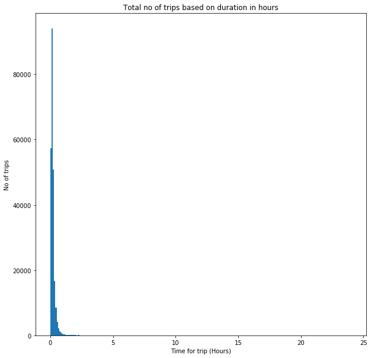

```python
#plot a histogram on normal scale
bins = np.arange(0, df['duration_hour'].max()+0.1, 0.1)
plt.figure(figsize=[10,10])
plt.hist(data = df, x = 'duration_hour', bins = bins)
plt.xlabel('Time for trip (Hours)')
plt.ylabel('No of trips')
plt.title('Total no of trips based on duration in hours')
plt.show()
```

We can see that most trip duration is less than 5 hours. Let's zoom in on the y-axis to see if there are any outliers present in the data

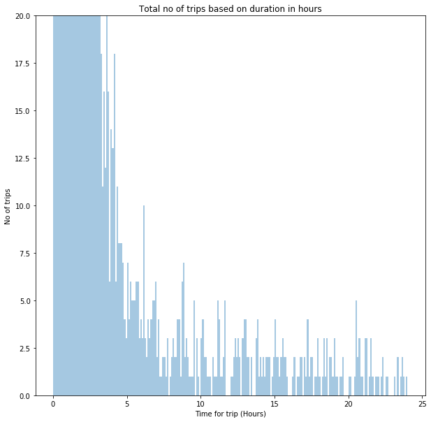

```python
plt.figure(figsize=[10,10])
bins = np.arange(0,df['duration_hour'].max()+0.1, 0.1)
sns.distplot(df['duration_hour'], bins = bins, kde = False);
plt.xlabel('Time for trip (Hours)')
plt.ylabel('No of trips')
plt.title('Total no of trips based on duration in hours')
plt.ylim(0,20);
```

We can see that the data is distributed till the end and no outliers are present and the data is skewed to the right. Now let's plot the data on a log scale

```python
log_scale  = np.log10(df['duration_hour'])
```

```python
log_scale.describe()
```

```
count    239047.000000
mean         -0.807415
std           0.317695
min          -1.698970
25%          -1.000000
50%          -0.795880
75%          -0.619789
max           1.378761
Name: duration_hour, dtype: float64
```

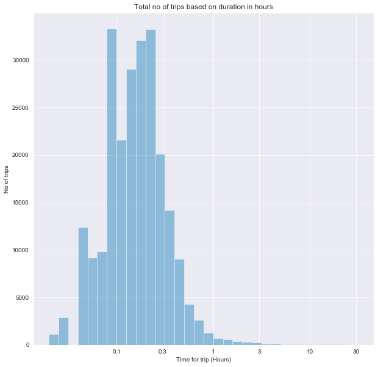

```python
# plot a histogram on a log scale
plt.figure(figsize=[10,10])
sns.set_style('darkgrid')
sns.set_palette('colorblind')
bins = 10** np.arange(-1.7,1.5+0.1, 0.1)
ticks = [0.1,0.3,1,3,10,30]
labels = ['{}'.format(v) for v in ticks]
sns.distplot(df['duration_hour'], bins = bins, kde = False);
plt.xlabel('Time for trip (Hours)')
plt.ylabel('No of trips')
plt.title('Total no of trips based on duration in hours')
plt.xscale('log');
plt.xticks(ticks,labels);
```

**Conclusion**

#### What are the most popular and the least popular start and stop stations?

Let's plot the top 10 most common start station in descending order

```python
#set base color
base_color = sns.color_palette()[0]
```

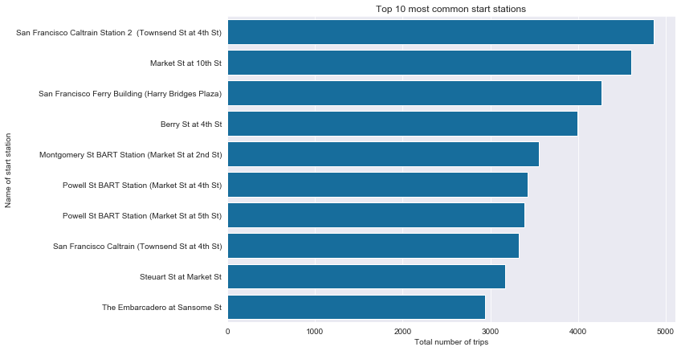

```python
plt.figure(figsize=(10,7));
df_order = df['start_station_name'].value_counts() #count the values in descending order
df_index = df_order.index #select the index i.e the station names
sns.countplot(data = df, y = 'start_station_name',order = df_index[:10], color = base_color ); #create a plot of the first 10 values
plt.xlabel('Total number of trips')
plt.ylabel('Name of start station')
plt.title('Top 10 most common start stations');
```

Let's also plot top 10 most common stop stations in decreasing order

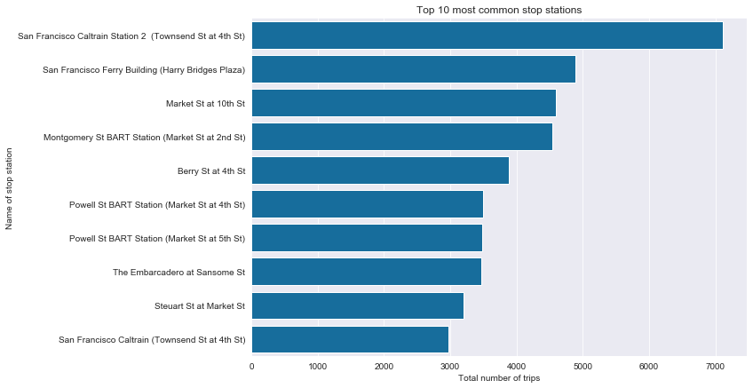

```python
plt.figure(figsize=(10,7));
df_order = df['end_station_name'].value_counts()
df_index = df_order.index
sns.countplot(data = df, y = 'end_station_name',order = df_index[:10], color = base_color );
plt.xlabel('Total number of trips')
plt.ylabel('Name of stop station')
plt.title('Top 10 most common stop stations');
```

Plotting the top 10 least common start stations

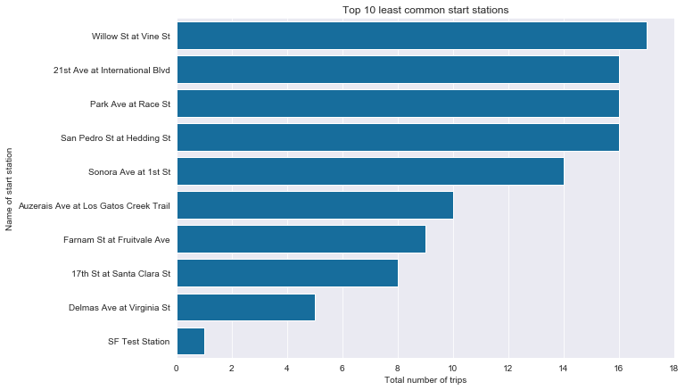

```python
plt.figure(figsize=(10,7));
df_order = df['start_station_name'].value_counts()
df_index = df_order.index
sns.countplot(data = df, y = 'start_station_name',order = df_index[-10:], color = base_color ); #select the last 10 values and plot them
plt.xlabel('Total number of trips')
plt.ylabel('Name of start station')
plt.title('Top 10 least common start stations');
x_labels = np.arange(0, 19, 2)
plt.xticks(x_labels, x_labels);
```

Let's now plot the top 10 least common stop stations

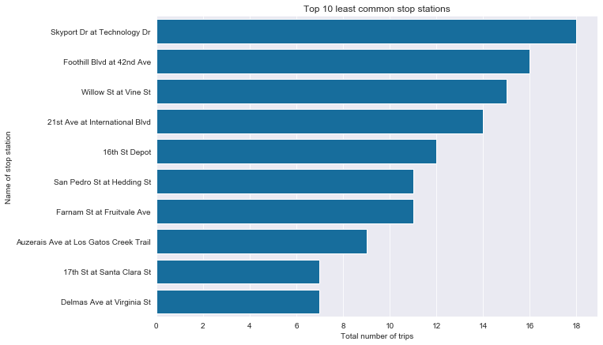

```python
plt.figure(figsize=(10,7));
df_order = df['end_station_name'].value_counts()
df_index = df_order.index
sns.countplot(data = df, y = 'end_station_name',order = df_index[-10:], color = base_color );
plt.xlabel('Total number of trips')
plt.ylabel('Name of stop station')
plt.title('Top 10 least common stop stations');
x_labels = np.arange(0, 19, 2)
plt.xticks(x_labels, x_labels);
```

**Conclusions**

We can see from the above visualizations that the most common start and stop station is *San Francisco Caltrain Station 2* with around 4800 start trips and around 7100 stop trips. *Market St at 10th st* and *San Francisco Ferry Building* are the second and third most common start and stop stations.

#### Which bike is most frequently used?

Let's plot a bar chart of the top 10 most common bike_id

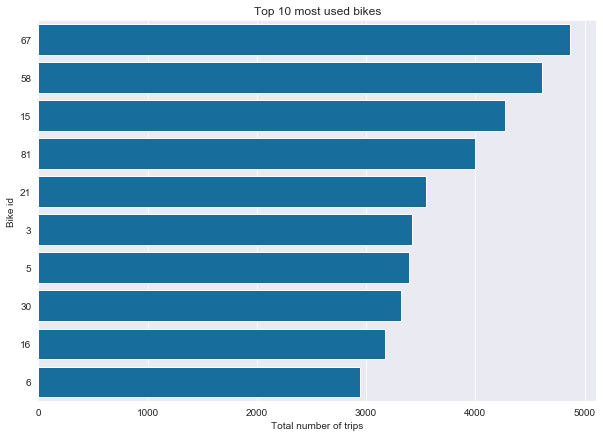

```python
plt.figure(figsize=(10,7));
df_order = df['bike_id'].value_counts()
df_index = df_order.index
sns.countplot(data = df, y = 'bike_id' , order = df_index[:10], color = base_color );
plt.xlabel('Total number of trips')
plt.ylabel('Bike id')
plt.title('Top 10 most used bikes');
```

#### How many users are there in each catergory type?

Let's create a bar chart with total number of user type for each category

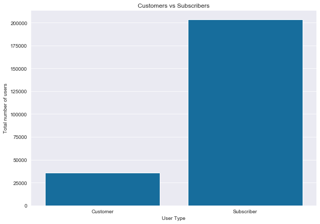

```python
plt.figure(figsize=(10,7));
sns.countplot(data = df, x = 'user_type', color = base_color);
plt.xlabel('User Type')
plt.ylabel('Total number of users')
plt.title('Customers vs Subscribers');
```

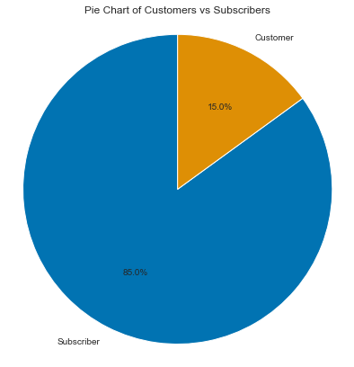

```python
plt.figure(figsize=(10,7))
sorted_counts = df['user_type'].value_counts()
plt.pie(sorted_counts, labels = sorted_counts.index, startangle = 90, autopct='%1.1f%%',);
plt.axis('square');
plt.title('Pie Chart of Customers vs Subscribers');
```

**Conclusions**

Hence we can see that 85% of the user type are subscribers and only 15% is customer type which is almost 1/5 of subscriber

#### What is the proportion of bike share for all trip?

Let's create a bar chart and a pie chart to see the proportion between bike share for all trips

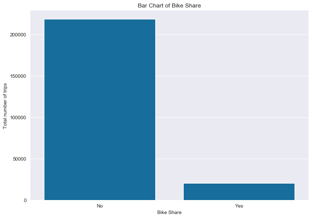

```python
plt.figure(figsize=(10,7));
sns.countplot(data = df, x = 'bike_share_for_all_trip', color = base_color);
plt.xlabel('Bike Share');
plt.ylabel('Total number of trips');
plt.title('Bar Chart of Bike Share');
```

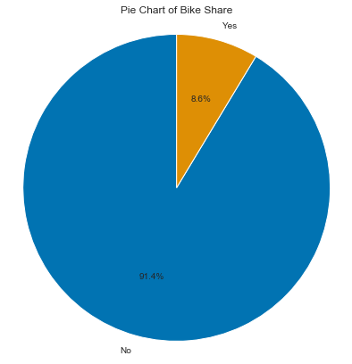

```python
plt.figure(figsize=(10,7))
sorted_counts = df['bike_share_for_all_trip'].value_counts()
plt.pie(sorted_counts, labels = sorted_counts.index, startangle = 90, autopct='%1.1f%%',);
plt.axis('square');
plt.title('Pie Chart of Bike Share');
```

**Conclusions**

Only in 8.6% of the total trip was the bike shared for all compared to 91.4% time it was not shared

#### Which day had most and least number of starting trips?

Let's create a bar chart for the start trips for the days of the week

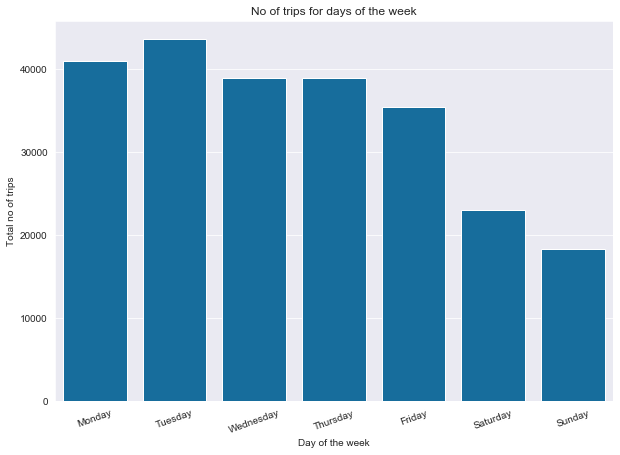

```python
plt.figure(figsize=(10,7));
order = ['Monday', 'Tuesday', 'Wednesday','Thursday','Friday','Saturday','Sunday']
sns.countplot(data = df, x = 'start_day',order=order, color = base_color);
plt.xticks(rotation = 20);
plt.title('No of trips for days of the week');
plt.xlabel('Day of the week');
plt.ylabel('Total no of trips');
```

**Conclusions**

Tuesday has the highest number of bike rides starting on that day followed by Monday and Wednesday. Sunday seems to have the least number of bike rides starting that day followed by Saturday.

The reason for this could be that most people use the bikes to commute to work hence weekdays have higher count than weekends but since we don't have enough data or information about it, we can only speculate. What we know with certainty is that for the month of April 2019, Weekdays had more trips starts compared to weekends

Let's see the number of user type for the same bar chart as above

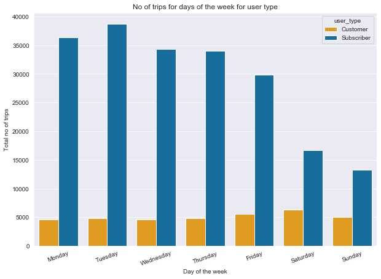

```python
plt.figure(figsize=(10,7));
order = ['Monday', 'Tuesday', 'Wednesday','Thursday','Friday','Saturday','Sunday']
sns.countplot(data = df, x = 'start_day',order=order,hue = 'user_type', palette = {'Customer':'orange','Subscriber':base_color} );
plt.xticks(rotation = 20);
plt.title('No of trips for days of the week for user type');
plt.xlabel('Day of the week');
plt.ylabel('Total no of trips');
```

**Conclusions**

We see that most of the users are subscribers who use the bike on any given day

#### What is the most common hour of the day when the trips starts?

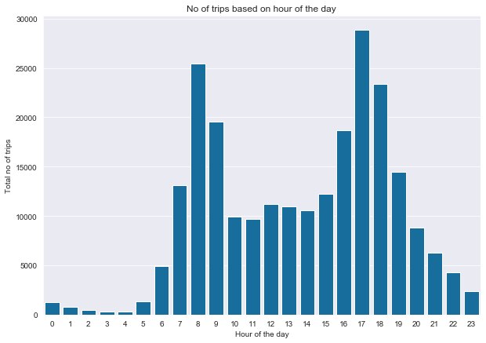

```python
plt.figure(figsize=(10,7));
sns.countplot(data = df, x = 'start_hour', color = base_color);
plt.title('No of trips based on hour of the day')
plt.xlabel('Hour of the day')
plt.ylabel('Total no of trips');
```

**Conclusion**

It can be seen from the above bar chart that most common start time for a trip is 5pm followed by 8 am and 6pm and 9am. I wonder if they are the same people going from home to work and vice versa

### Bivariate Exploration

Let's create a joint plot to see the differences between the latitudes and longitudes

```python
#removing outliers i.e. points when difference between latitude or longitude is greater than 1 or less than -1
df = df[(df['latitude_diff']<1) & (df['latitude_diff']>-1)]
```

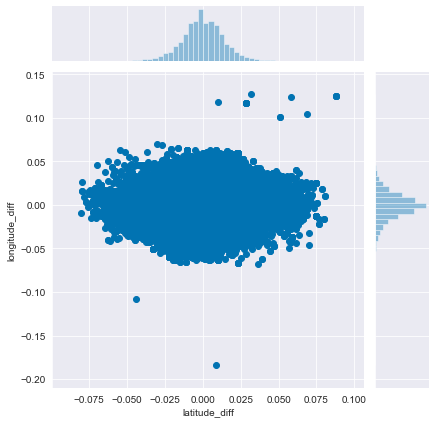

```python
sns.jointplot(data= df, x = 'latitude_diff', y = 'longitude_diff');
```

**Conclusions**

The different in latitudes and longitudes seems to be normally distributed as seen in the histograms on the top and on the right. There are only a few outliers present that can be seen from the scatter plot in the center. It can also be observed from the scatter plot that most of the trips have very less difference in the latitudes and longitudes

Let's create a scatter plot to see the latitude and longitude difference between the two user types

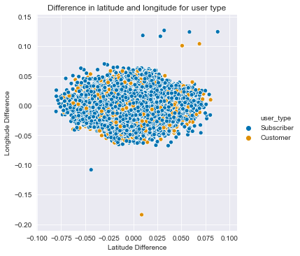

```python
sns.relplot(data = df, x='latitude_diff', y='longitude_diff', hue = 'user_type');
plt.xlabel('Latitude Difference')
plt.ylabel('Longitude Difference')
plt.title('Difference in latitude and longitude for user type');
```

**Conclusions**

Mostly there is not much difference in the longitude and latitude for both the user types. It can be seen that a few of the customer user types are present in the outliers

Let's create some violin plot to look at the relationship between the categorical variables and numeric variables

[figure not shown]

```python
#create a violin plot of the difference in longitude for various user types
plt.figure(figsize=(10,7));
sns.violinplot(data = df, x = 'user_type' , y = 'longitude_diff');
plt.xlabel('User type')
plt.ylabel('Difference in longitude')
plt.title('Difference in latitude for user type');
```

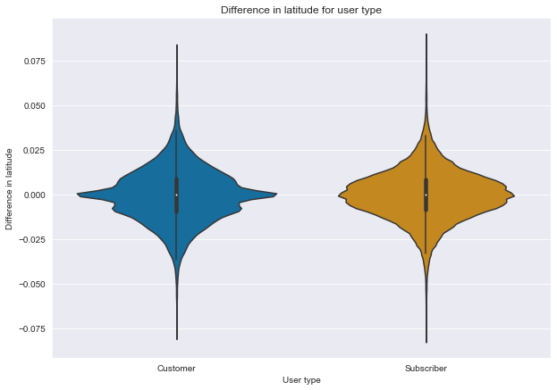

```python
#create a violin plot of the difference in latitude for various user types
plt.figure(figsize=(10,7));
sns.violinplot(data = df , x = 'user_type' , y = 'latitude_diff');
plt.xlabel('User type')
plt.ylabel('Difference in latitude')
plt.title('Difference in latitude for user type');
```

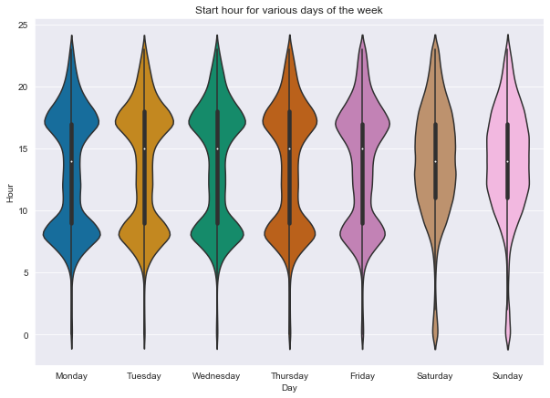

```python
#create a violin plot of the start day and start hour
plt.figure(figsize=(10,7));
sns.violinplot(data = df , x = 'start_day' , y = 'start_hour', order = order);
plt.xlabel('Day')
plt.ylabel('Hour')
plt.title('Start hour for various days of the week');
```

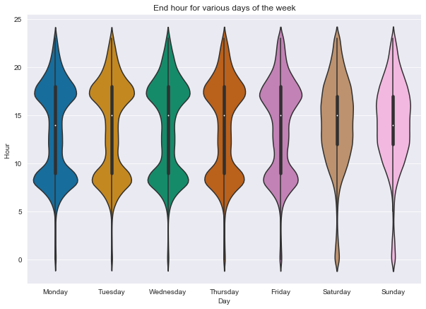

```python
##create a violin plot of the start day and end hour
plt.figure(figsize=(10,7));
sns.violinplot(data = df , x = 'start_day' , y = 'end_hour', order = order);
plt.xlabel('Day')
plt.ylabel('Hour ')
plt.title('End hour for various days of the week');
```

**Conclusions**

It can be seen from the above violin plots that most of the trips start around 8 am to 9 am or 5 pm to 6 pm on the weekdays. On the weekend this trend changes and most of the start hour and end hour seem to fall approximately between 12 pm and 6 pm

Lets look at the average duration in minutes for different days of the month

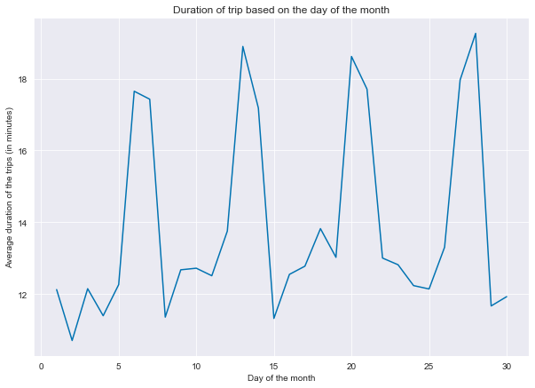

```python
plt.figure(figsize=(10,7));
sns.lineplot(data = df, x = 'start_date', y = 'duration_min', err_style = None);
plt.xlabel('Day of the month')
plt.ylabel('Average duration of the trips (in minutes)')
plt.title('Duration of trip based on the day of the month');
```

[figure not shown]

```python
#seperating the average duration for the two user types
plt.figure(figsize=(10,7));
sns.lineplot(data = df, x = 'start_date', y = 'duration_min',hue = 'user_type', err_style = None);
plt.xlabel('Day of the month')
plt.ylabel('Average duration of the trips (in minutes)')
plt.title('Distribution of duration of trip of riders based on their age');
```

**Conclusions**

It can be seen from the first graph that the average duration of trips spikes around 6th, 13th, 20th and 27th of the month. The second graph shows the same information but we can see that the average duration of trips for customers is greater than that of subscribers with least duration of trip for the customer being around 17 minutes while the highest duration for a subscriber is only around 14 minutes. Thus we can conclude that customers had higher average trip duration on any given day compared to subscribers for the month of April 2019

### Multivariate Exploration

```python
#create seperate lists for numerical variables and categorical variables
num_var = ['duration_sec', 'start_station_latitude', 'start_station_longitude', 'end_station_latitude',
                'end_station_longitude', 'start_hour']
cat_var = ['user_type', 'bike_share_for_all_trip']
```

Let's plot a correlation plot of the different numeric variables

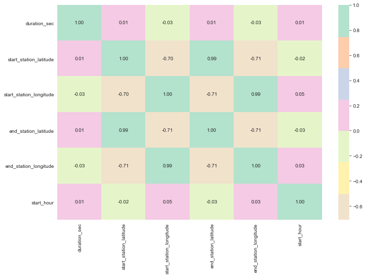

```python
# correlation plot
plt.figure(figsize = [12, 8])
sns.heatmap(df[num_var].corr(), annot = True, fmt = '.2f',
           cmap = 'Pastel2_r', center = 0)

plt.show()
```

From the above plot we can see that there is a high positive or negative correlation between a few variables. These are as follows:-

**High Positive Correlation**

- start station longitude vs end station longitude
- start station latitude vs end station latitude

**High Negative Correlation**

- start station latitude vs start station longitude
- start station longitude vs end station latitude
- end station longitude vs end station latitude

Let's create a pairwise grid plot for the above numeric variables. To reduce the computation time and for clarity of the plots, we are going to choose a sample of 1000

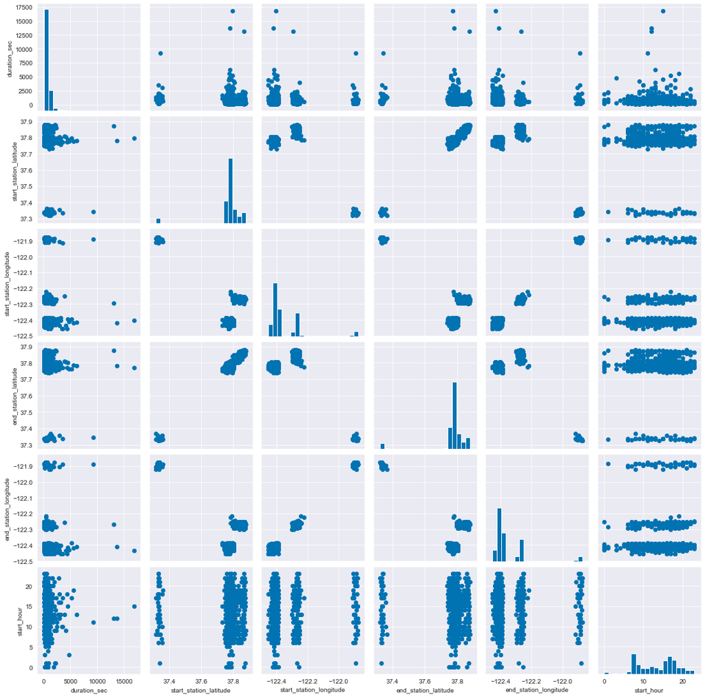

```python
#create pairwise grid plot of 1000 samples
g = sns.PairGrid(data = df.sample(1000), vars = num_var)
g = g.map_diag(plt.hist, bins = 20); #plot histograms on the diagonal axis
g.map_offdiag(plt.scatter); #scatter plot on off diagonal axis
```

**Conclusions**

```python
#save to csv
df.to_csv('fordgo_clean.csv')
```